# loan_prediction

Xiang Gao

2023-09-05

# Justification: In the next code block, I will install all necessary non-standard libraries.

```r
#install labraries if they are not installed.
if (!("dplyr" %in% installed.packages()[,"Package"])){
install.packages("dplyr")}

if (!("ggplot2" %in% installed.packages()[,"Package"])){
install.packages("ggplot2")}

if (!("tidyr" %in% installed.packages()[,"Package"])){
install.packages("tidyr")}

if (!("tidyverse" %in% installed.packages()[,"Package"])){
install.packages("tidyverse")}

if (!("tidymodels" %in% installed.packages()[,"Package"])){
install.packages("tidymodels")}

if (!("vip" %in% installed.packages()[,"Package"])){
install.packages("vip")}

if (!("xgboost" %in% installed.packages()[,"Package"])){
install.packages("xgboost")}

if (!("baguette" %in% installed.packages()[,"Package"])){
install.packages("baguette")}

if (!("randomForest" %in% installed.packages()[,"Package"])){
install.packages("randomForest")}
```

# Justification: In the next code block, I will load all necessary libraries for later use.

```r
library(dplyr)
```

```r
library(ggplot2)
library(tidyr)
library(tidyverse)
library(tidymodels)
library(vip)
library(xgboost)
library(baguette)
```

# Justification: In the next code block, I will load the data file including historical data about home loan applications and approval or denial.

```r
#load the raw data
historical_data <- read.csv("state_PA_actions_taken.csv")
```

# Justification: In the next code block, I will discover the data based on primary information and descriptive statistics.

```r
#the number of columns and rows
ncol(historical_data)
```

```
## [1] 99
```

```r
nrow(historical_data)
```

```
## [1] 363723
```

```r
summary(historical_data)
```

```
##  activity_year      lei            derived_msa.md   state_code
##  Min.   :2019   Length:363723      Min.   :    0   Length:363723
##  1st Qu.:2019   Class :character   1st Qu.:33874   Class :character
##  Median :2019   Mode  :character   Median :37964   Mode  :character
##  Mean   :2019                      Mean   :39511
##  3rd Qu.:2019                      3rd Qu.:38300
##  Max.   :2019                      Max.   :99999
##
##   county_code     census_tract       conforming_loan_limit
##  Min.   : 1043   Min.   :1.044e+09   Length:363723
##  1st Qu.:42019   1st Qu.:4.202e+10   Class :character
##  Median :42065   Median :4.207e+10   Mode  :character
##  Mean   :42060   Mean   :4.206e+10
##  3rd Qu.:42095   3rd Qu.:4.210e+10
##  Max.   :51041   Max.   :5.104e+10
##  NA's   :1447    NA's   :1553
##  derived_loan_product_type derived_dwelling_category derived_ethnicity
##  Length:363723             Length:363723             Length:363723
##  Class :character          Class :character          Class :character
##  Mode  :character          Mode  :character          Mode  :character
##
##
##
##
##  derived_race       derived_sex         action_taken   purchaser_type
##  Length:363723      Length:363723      Min.   :1.000   Min.   : 0.000
##  Class :character   Class :character   1st Qu.:1.000   1st Qu.: 0.000
##  Mode  :character   Mode  :character   Median :1.000   Median : 0.000
##                                        Mean   :1.452   Mean   : 6.995
##                                        3rd Qu.:1.000   3rd Qu.: 2.000
##                                        Max.   :3.000   Max.   :72.000
##
##   preapproval      loan_type      loan_purpose    lien_status
##  Min.   :1.000   Min.   :1.000   Min.   : 1.00   Min.   :1.000
##  1st Qu.:2.000   1st Qu.:1.000   1st Qu.: 1.00   1st Qu.:1.000
##  Median :2.000   Median :1.000   Median : 2.00   Median :1.000
##  Mean   :1.986   Mean   :1.244   Mean   :12.71   Mean   :1.223
##  3rd Qu.:2.000   3rd Qu.:1.000   3rd Qu.:31.00   3rd Qu.:1.000
##  Max.   :2.000   Max.   :4.000   Max.   :32.00   Max.   :2.000
##
```

[output cut: 209 more lines]

```
##  Min.   :  0.0                  Min.   :   0
##  1st Qu.: 88.0                  1st Qu.: 949
##  Median :105.0                  Median :1361
##  Mean   :110.1                  Mean   :1408
##  3rd Qu.:125.0                  3rd Qu.:1789
##  Max.   :443.0                  Max.   :3551
##
##  tract_one_to_four_family_homes tract_median_age_of_housing_units
##  Min.   :   0                   Min.   : 0.00
##  1st Qu.:1349                   1st Qu.:36.00
##  Median :1803                   Median :46.00
##  Mean   :1871                   Mean   :48.26
##  3rd Qu.:2363                   3rd Qu.:61.00
##  Max.   :6522                   Max.   :76.00
##
```

# Justification: Now, I can see that the raw data has 99 columns, 98 of which are possible features and the other one is the label. In order to reduce the complexity of the model, I need to discard some invalid columns in the next code block. Specific reasons are provided in the comments adjacent to the corresponding code.

```r
feature_discard <- c()

#The feature activity_year for all data is 2019, making this column meaningless for prediction.
feature_discard <- c(feature_discard,"activity_year")

#Some features indicate the area of applicant.
##Since census_tract is an overloaded feature which includes the information of the state and county, we will unpack it later and discard other features consequently.
feature_discard <- c(feature_discard,"derived_msa.md")
feature_discard <- c(feature_discard,"state_code")
feature_discard <- c(feature_discard,"county_code")
feature_discard <- c(feature_discard,"ffiec_msa_md_median_family_income")

#Some features can be discarded since we have already extract important information from them and store it to other columns (derived_ethnicity, derived_race, derived_sex, etc.) .
feature_discard <- c(feature_discard,"applicant_ethnicity.1")
feature_discard <- c(feature_discard,"applicant_ethnicity.2")
feature_discard <- c(feature_discard,"applicant_ethnicity.3")
feature_discard <- c(feature_discard,"applicant_ethnicity.4")
feature_discard <- c(feature_discard,"applicant_ethnicity.5")

feature_discard <- c(feature_discard,"co.applicant_ethnicity.1")
feature_discard <- c(feature_discard,"co.applicant_ethnicity.2")
feature_discard <- c(feature_discard,"co.applicant_ethnicity.3")
feature_discard <- c(feature_discard,"co.applicant_ethnicity.4")
feature_discard <- c(feature_discard,"co.applicant_ethnicity.5")
feature_discard <- c(feature_discard,"applicant_ethnicity_observed")
feature_discard <- c(feature_discard,"co.applicant_ethnicity_observed")

feature_discard <- c(feature_discard,"applicant_race.1")
feature_discard <- c(feature_discard,"applicant_race.2")
feature_discard <- c(feature_discard,"applicant_race.3")
feature_discard <- c(feature_discard,"applicant_race.4")
feature_discard <- c(feature_discard,"applicant_race.5")

feature_discard <- c(feature_discard,"co.applicant_race.1")
feature_discard <- c(feature_discard,"co.applicant_race.2")
feature_discard <- c(feature_discard,"co.applicant_race.3")
feature_discard <- c(feature_discard,"co.applicant_race.4")
feature_discard <- c(feature_discard,"co.applicant_race.5")

feature_discard <- c(feature_discard,"applicant_race_observed")
feature_discard <- c(feature_discard,"co.applicant_race_observed")

feature_discard <- c(feature_discard,"applicant_sex")
feature_discard <- c(feature_discard,"applicant_sex_observed")

feature_discard <- c(feature_discard,"co.applicant_sex")
feature_discard <- c(feature_discard,"co.applicant_sex_observed")

feature_discard <- c(feature_discard,"applicant_age_above_62")
feature_discard <- c(feature_discard,"co.applicant_age_above_62")

#We will also discard denial reasons since they our model will be trained by data of features instead of conclusions.
feature_discard <- c(feature_discard,"denial_reason.1")
feature_discard <- c(feature_discard,"denial_reason.2")
feature_discard <- c(feature_discard,"denial_reason.3")
feature_discard <- c(feature_discard,"denial_reason.4")
```

# Justification: In the next code block, I will group features into different parts according to the information they relates to. In the later, I will check these features carefully and determine whether to include them to train the model. Specific reasons are provided in the comments adjacent to the corresponding code.

```r
#These features indicate the applicant's district-related information.
feature_area <- c("census_tract","tract_population","tract_minority_population_percent","tract_to_msa_income_percentage","tract_owner_occupied_units","tract_one_to_four_family_homes","tract_median_age_of_housing_units")

#These features indicate the applicant's financial institution-related information.
feature_financial <- c("lei","purchaser_type","submission_of_application","initially_payable_to_institution")

#These features indicate the applicant's loan information.
##Some of them are categorical features.
feature_loan_categorical <- c("derived_loan_product_type","derived_dwelling_category","conforming_loan_limit","preapproval","loan_type","loan_purpose","lien_status","reverse_mortgage","open.end_line_of_credit","business_or_commercial_purpose","hoepa_status","negative_amortization","interest_only_payment","balloon_payment","other_nonamortizing_features","construction_method","occupancy_type","manufactured_home_secured_property_type","manufactured_home_land_property_interest")

##Some of them are numerical features.
feature_loan_numerical <- c("loan_amount","loan_to_value_ratio","interest_rate","rate_spread","total_loan_costs","total_points_and_fees","origination_charges","discount_points","lender_credits","loan_term","prepayment_penalty_term","intro_rate_period","property_value","total_units","multifamily_affordable_units")

#These features indicate applicant's personal info.
feature_privacy <- c("derived_ethnicity","derived_race","derived_sex",
                     "applicant_age","co.applicant_age","income","debt_to_income_ratio",
                     "applicant_credit_score_type","co.applicant_credit_score_type")

#These features indicate the underwriting system for application.
feature_aus <- c("aus.1","aus.2","aus.3","aus.4","aus.5")

#check if I omit any features
setdiff(colnames(historical_data),
        c(feature_area,
          feature_financial,
          feature_loan_categorical,
          feature_loan_numerical,
          feature_privacy,
          feature_aus,
          feature_discard)
        )
```

```
## [1] "action_taken"
```

```r
#I can see that the remain column action_taken is the label.
target <- c("action_taken")
```

# Justification: In the next code block, I will explore features relating to financial institution and then deal with their missing values. In the end I will discard some features which have little impact on the prediction. Specific reasons are provided in the comments adjacent to the corresponding code.

```r
financial_data <- historical_data[,c(feature_financial,target)]

#check the NA value
print(sum(is.na(financial_data$lei)))
```

```
## [1] 0
```

```r
print(sum(is.na(financial_data$purchaser_type)))
```

```
## [1] 0
```

```r
print(sum(is.na(financial_data$submission_of_application)))
```

```
## [1] 0
```

```r
print(sum(is.na(financial_data$initially_payable_to_institution)))
```

```
## [1] 0
```

```r
#check the number of classes for each feature
print(length(unique(financial_data$lei)))
```

```
## [1] 1035
```

```r
print(length(unique(financial_data$purchaser_type)))
```

```
## [1] 11
```

```r
print(length(unique(financial_data$submission_of_application)))
```

```
## [1] 3
```

```r
print(length(unique(financial_data$initially_payable_to_institution)))
```

```
## [1] 4
```

```r
#each column is a categorical feature and has no NA values. Since there are more than 1000 financial institutions in our dataset, it is too computationally expensive to conduct one-hot coding for it. We need to analyze it and divide similar institutions into one group.

#explore the approval/denial ratio for each financial institution.
financial_institution <- data.frame(lei = unique(financial_data$lei))

#count the number of cases for approval and denial.
financial_institution_approval <- financial_data |>
  filter(action_taken == 1) |>
  group_by(lei) |>
  summarize(approval = n())

financial_institution_denial <- financial_data |>
  filter(action_taken == 3) |>
  group_by(lei) |>
  summarize(denial = n())

#join two tables to count the ratio: approval/denial
financial_institution <- left_join(financial_institution,
                                  financial_institution_approval,by="lei")

financial_institution <- left_join(financial_institution,
                                  financial_institution_denial,by="lei")

financial_institution$approval <- replace_na(financial_institution$approval, 0)
financial_institution$denial <- replace_na(financial_institution$denial, 0)

financial_institution[1:100,]
```

```
##                      lei approval denial
## 1   6BYL5QZYBDK8S7L73M02      779    551
## 2   549300CB67L6KPJLHE19       77    451
## 3   FVPV0TNOIM6NUIE59530        4      2
## 4   N8T7HW55LK5D2ORCKP39     7056   2743
## 5   H98JYKDFKFZ5ZPCSMT69        3      0
## 6   549300VCMRO4ST680C11      192     46
## 7   549300LYRWPSYPK6S325     2666    529
## 8   54930049L5WINET09Q97       20      0
## 9   549300CDGL2OULMP7388      208     32
## 10  549300E3UCOTNUZIEB53       93     41
## 11  549300FK7ZHTO2G1RM11       36      0
## 12  MMO6VV34TNP4Z1T8NG83       23      4
## 13  549300B3O78O3WRVJJ49        3      0
## 14  5493000UZ37PYF2QMT96       36      0
```

[output cut: 86 more lines]

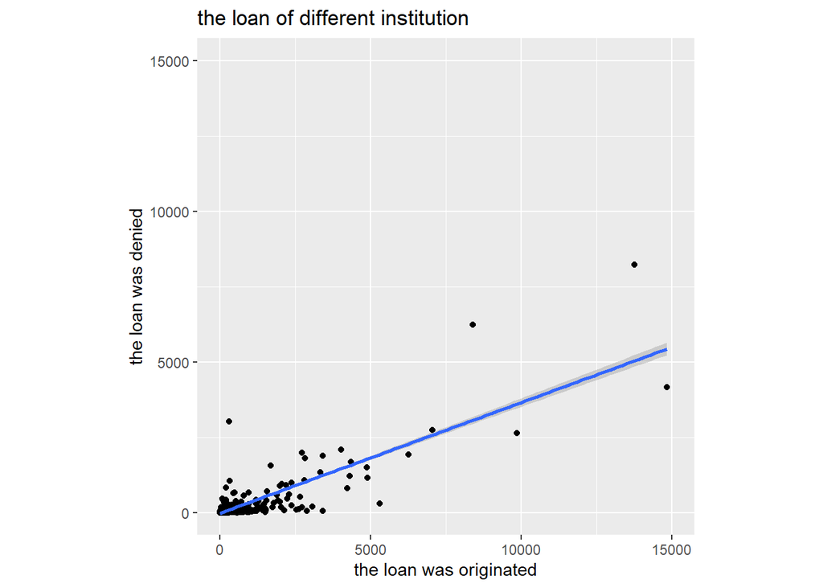

```r
#draw a scatter plot to check the approval/denial ratios for different institutions.
ggplot(financial_institution, aes(x = approval, y = denial)) +
  geom_point() +
  geom_smooth(method = "lm") +
  coord_fixed(ratio = 1, xlim = c(0, 15000), ylim = c(0, 15000)) +
  ggtitle("the loan of different institution") +
  xlab("the loan was originated") +
  ylab("the loan was denied")
```

```r
#I can conclude that the approval/denial ratios vary from one financial institution to another. We will not discard the seeming outliers because these don't just represent a particular institution, they represent the thousands of applicants who lend there. Instead, I will divided them into three parts - Institution of high approval, medium approval, and low approval.

#using Laplace smoothing to calculate the approval ratio
financial_institution$ratio <- (financial_institution$approval +1) /(financial_institution$denial +1)

summary(financial_institution$ratio)
```

```
##     Min.  1st Qu.   Median     Mean  3rd Qu.     Max.
##   0.0312   2.0000   4.0000  10.1498   9.1965 559.0000
```

```r
#I divided them into three parts representing low,medium, and high level of approval ratio and then conduct one-hot coding.
q1 <- quantile(financial_institution$ratio,0.25)
q3 <- quantile(financial_institution$ratio,0.75)
approval_ratio_split <- function(value) {
    approval_ratio_level = 0
  if (value >= q3) {
    approval_ratio_level =2
  } else if (value >= q1 && value < q3) {
    approval_ratio_level =1
  } else {
    approval_ratio_level =0
  }
  return(approval_ratio_level)
}

financial_institution$ratio_type <- sapply(financial_institution$ratio,
                                          approval_ratio_split)


# merge approval_ratio to financial dataframe
financial_data <- left_join(financial_data,financial_institution[,c("lei","ratio_type")],by="lei")

#process financial institution-related data for modeling
financial_data$action_taken <- ifelse(financial_data$action_taken == 1, 1, 0)

#prepare data for applying random forest algorithm
financial_data$purchaser_type<-as.factor(financial_data$purchaser_type)
financial_data$submission_of_application<-as.factor(financial_data$submission_of_application)
financial_data$initially_payable_to_institution<-as.factor(financial_data$initially_payable_to_institution)
financial_data$action_taken<-as.factor(financial_data$action_taken)
financial_data$ratio_type<-as.factor(financial_data$ratio_type)

financial_data <- select(financial_data,-c("lei"))

#Now, I will finish this part by applying the random forest algorithm.
#In order to save computational resources, we just use a fraction of the whole instances to train the model. I won't validate them since I only care the importance of features instead of the performance of the model.

#use the 10% of dataset to create training set and testing set
split <- initial_split(financial_data[sample(nrow(financial_data), size = 0.1 * nrow(financial_data)),], prop=0.80)

# Assign training instances to training_data
training_data <- training(split)

# Assign testing instances to testing_data
testing_data <- testing(split)

financial_recipe <- recipe(action_taken ~ .,
  data = training_data) |>
  step_dummy(all_nominal_predictors())

rfModel <- rand_forest(mode = "classification",
  engine = "randomForest",
  mtry = 4,
  min_n = 100)

financial_workflow <- workflow() |>
  add_model(rfModel) |>
  add_recipe(financial_recipe)


rfModel_fit <- financial_workflow |>
  fit(data = training_data)

# Variable importance table
rfModel_fit |>
  extract_fit_parsnip() |>
  vi()
```

```
## # A tibble: 17 × 2
##    Variable                               Importance
##    <chr>                                       <dbl>
##  1 initially_payable_to_institution_X3        520.
##  2 ratio_type_X2                              502.
##  3 ratio_type_X1                              389.
##  4 purchaser_type_X1                          319.
##  5 purchaser_type_X3                          226.
##  6 purchaser_type_X2                          207.
##  7 purchaser_type_X71                         195.
##  8 purchaser_type_X6                          112.
##  9 purchaser_type_X9                           52.2
## 10 submission_of_application_X2                28.3
## 11 submission_of_application_X1111             11.1
## 12 initially_payable_to_institution_X1111      10.6
## 13 initially_payable_to_institution_X2          9.99
## 14 purchaser_type_X5                            7.06
## 15 purchaser_type_X72                           5.15
## 16 purchaser_type_X8                            3.62
## 17 purchaser_type_X4                            0
```

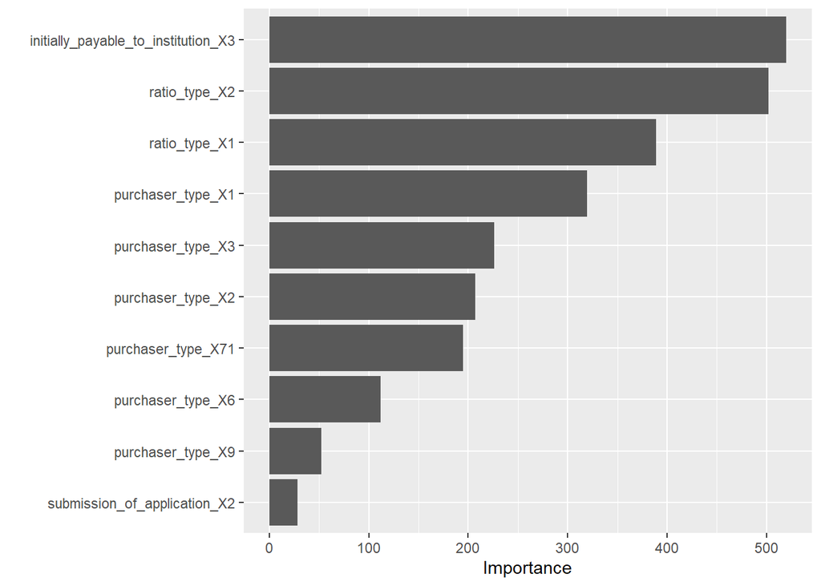

```r
# Variable importance plot
rfModel_fit |>
  extract_fit_parsnip() |>
  vip()
```

```r
#This accuracy is acceptable.
testPred <- augment(rfModel_fit, testing_data)
testPred |> accuracy(action_taken, .pred_class)
```

```
## # A tibble: 1 × 3
##   .metric  .estimator .estimate
##   <chr>    <chr>          <dbl>
## 1 accuracy binary         0.814
```

```r
#Here, we can conclude that the most important features related to financial institution are initially_payable_to_institution and ratio_type. I will use them to train our predictive model and discard other features.
historical_data <- left_join(historical_data,
                             rename(financial_institution[,c("lei","ratio_type")],
                                    financial_institution_ratio_type = ratio_type),
                             by="lei")

#I will keep these features for training data.
feature_financial <- c("initially_payable_to_institution",
                       "financial_institution_ratio_type")

#I will discard these because they are not very important or more important information has already extracted from them.
feature_discard <- c(feature_discard,c("submission_of_application",
                                       "purchaser_type",
                                       "lei"))
```

# Justification: In the next code block, I will explore features relating to district information and then deal with their missing values. In the end I will discard some features have little impact on the prediction. Specific reasons are provided in the comments adjacent to the corresponding code.

```r
#These features indicate the applicant's district-related information.
area_data <- historical_data[,c(feature_area,target)]

#check the NA value
print(sum(is.na(area_data$census_tract)))
```

```
## [1] 1553
```

```r
print(sum(is.na(area_data$tract_population)))
```

```
## [1] 0
```

```r
print(sum(is.na(area_data$tract_minority_population_percent)))
```

```
## [1] 0
```

```r
print(sum(is.na(area_data$tract_to_msa_income_percentage)))
```

```
## [1] 0
```

```r
print(sum(is.na(area_data$tract_owner_occupied_units)))
```

```
## [1] 0
```

```r
print(sum(is.na(area_data$tract_one_to_four_family_homes)))
```

```
## [1] 0
```

```r
print(sum(is.na(area_data$tract_median_age_of_housing_units)))
```

```
## [1] 0
```

```r
#As I mentioned before, census_tract is an overloaded feature and it also has 1553 NA values, so let me discover it first.
area_data[is.na(area_data$census_tract),][1:100,]
```

```
##       census_tract tract_population tract_minority_population_percent
## 20              NA                0                                 0
## 14474           NA                0                                 0
## 14504           NA                0                                 0
## 14505           NA                0                                 0
## 14506           NA                0                                 0
## 14507           NA                0                                 0
## 14508           NA                0                                 0
## 14509           NA                0                                 0
## 14510           NA                0                                 0
## 14511           NA                0                                 0
## 14512           NA                0                                 0
## 14513           NA                0                                 0
## 14514           NA                0                                 0
## 14515           NA                0                                 0
```

[output cut: 389 more lines]

```r
#We can see that for rows where census_tract is a null value, the values in other columns are also zero, we can simply omit them when discovering the features.
area_data <- area_data[!is.na(area_data$census_tract),]

#According to the definition, the census_tract contains information of state,county and tract code.
## As all data is from PA state, now we only care the county and tract code.
unique(historical_data$state_code)
```

```
## [1] "PA"
```

```r
#So I will unpack the census_tract feature by splitting it into just two columns, census_county_code and census_tract_code.
area_data$census_county_code <- substr(area_data$census_tract, start = 4, stop = 6)
area_data$census_tract_code <- substr(area_data$census_tract, start = 7, stop = 12)

#Too many classes are included in the census_tract_code. Its high cardinality will make the model computationally expensive to train. So I have to discard it and only hold the county code to represent the location.
length(unique(area_data$census_county_code))
```

```
## [1] 76
```

```r
length(unique(area_data$census_tract_code))
```

```
## [1] 1385
```

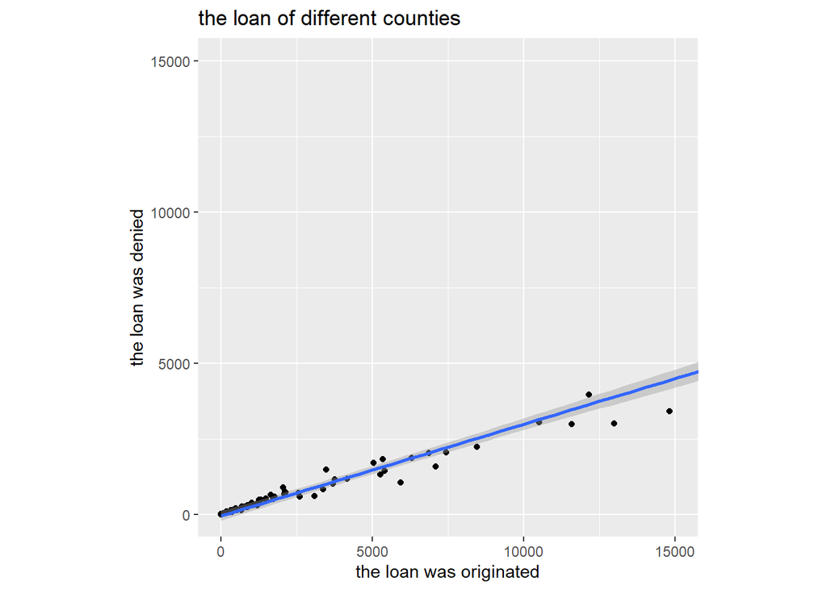

```r
area_data <- select(area_data,-c("census_tract_code"))

#As with financial institutions, I would draw a scatter plot to see if there are significant differences in approval/denial ratio between counties.
area_county <- data.frame(census_county_code = unique(area_data$census_county_code))

census_county_approval <- area_data |>
  filter(action_taken == 1) |>
  group_by(census_county_code) |>
  summarize(approval = n())

census_county_denial <- area_data |>
  filter(action_taken == 3) |>
  group_by(census_county_code) |>
  summarize(denial = n())

area_county <- left_join(area_county,census_county_approval
                         ,by="census_county_code")

area_county <- left_join(area_county,census_county_denial
                         ,by="census_county_code")

area_county$approval <- replace_na(area_county$approval, 0)
area_county$denial <- replace_na(area_county$denial, 0)

#draw a scatter plot to check the approval/denial ratios for different institutions.
ggplot(area_county, aes(x = approval, y = denial)) +
  geom_point() +
  geom_smooth(method = "lm") +
  coord_fixed(ratio = 1, xlim = c(0, 15000), ylim = c(0, 15000)) +
  ggtitle("the loan of different counties") +
  xlab("the loan was originated") +
  ylab("the loan was denied")
```

```r
#I can conclude that almost all the points align closely with the trend line, which indicates minimal variation in the approval ratio across different counties. So I will discard this feature as it contributes limited to the predictive model.
area_data <- select(area_data,-c("census_county_code"))
area_data <- select(area_data,-c("census_tract"))


#For the other six district-related numerical features, it seems that they might be associated with each other and may be able to be combined into fewer latent variables such as applicants' average income, family, and housing situation. I will apply PCA to find orthogonal components.
area_data_numerical <-area_data[,c("tract_population",
                                   "tract_minority_population_percent",
                                   "tract_to_msa_income_percentage",
                                   "tract_owner_occupied_units",
                                   "tract_one_to_four_family_homes",
                                   "tract_median_age_of_housing_units")]

#scale the features
area_data_numerical_scaled <- scale(area_data_numerical)
area_data_numerical_scaled <- as.data.frame(area_data_numerical_scaled)

# Assign training instances to training_data
split <- initial_split(area_data_numerical_scaled, prop=0.80)
training_data <- training(split)
pca_result <- princomp(training_data, cor = TRUE)

#leveling off point indicates the Comp.3
summary(pca_result)
```

```
## Importance of components:
##                           Comp.1    Comp.2    Comp.3     Comp.4     Comp.5
## Standard deviation     1.7904611 1.1598045 0.8461333 0.73178962 0.35736778
## Proportion of Variance 0.5342918 0.2241911 0.1193236 0.08925267 0.02128529
## Cumulative Proportion  0.5342918 0.7584829 0.8778065 0.96705916 0.98834444
##                            Comp.6
## Standard deviation     0.26444911
## Proportion of Variance 0.01165556
## Cumulative Proportion  1.00000000
```

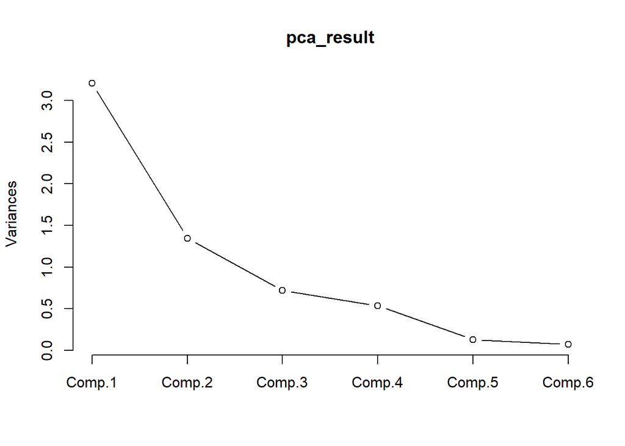

```r
plot(pca_result, type = "lines")
```

```r
#From the Scree plots, we can conclude that we only need to select three factors instead of six. which might align with my hypothesis, the factors of income, family and housing.I will extract the first three important factors from the complete subset and incorporate them back into the overall data for subsequent calculation.
historical_data_PCA <- historical_data[,c("tract_population",
                                   "tract_minority_population_percent",
                                   "tract_to_msa_income_percentage",
                                   "tract_owner_occupied_units",
                                   "tract_one_to_four_family_homes",
                                   "tract_median_age_of_housing_units")]

pca_historical_result <- princomp(historical_data_PCA, cor = TRUE)
area_pca_data <- data.frame(area_pca_1=pca_historical_result$scores[, 1],
                            area_pca_2=pca_historical_result$scores[, 2],
                            area_pca_3=pca_historical_result$scores[, 3])
historical_data <- cbind(historical_data,area_pca_data)

#I will use these three pca factor features and the other district-related features.
feature_area <- c("area_pca_1",
                  "area_pca_2",
                  "area_pca_3")

#I will discard these because they are not very important or more important information has already extracted from them.
feature_discard <- c(feature_discard,c( "census_tract",
                                        "tract_population",
                                        "tract_minority_population_percent",
                                        "tract_to_msa_income_percentage",
                                        "tract_owner_occupied_units",
                                        "tract_one_to_four_family_homes",
                                        "tract_median_age_of_housing_units"))
```

# Justification: In the next code block, I will explore features relating to underwriting system information and then deal with their missing values. In the end I will discard some features have little impact on the prediction. Specific reasons are provided in the comments adjacent to the corresponding code.

```r
#These features indicate the underwriting system information for application.
aus_data <- historical_data[,c(feature_aus,target)]

#check the NA value
print(sum(is.na(aus_data$aus.1)))
```

```
## [1] 0
```

```r
print(sum(is.na(aus_data$aus.2)))
```

```
## [1] 347094
```

```r
print(sum(is.na(aus_data$aus.3)))
```

```
## [1] 356569
```

```r
print(sum(is.na(aus_data$aus.4)))
```

```
## [1] 359343
```

```r
print(sum(is.na(aus_data$aus.5)))
```

```
## [1] 359967
```

```r
#The aus.2 to aus.5 columns contain at least 95% NA values, we can just discard them. Then inspect the aus.1. I will discard these because they are not very important.
feature_discard <- c(feature_discard,c("aus.2","aus.3", "aus.4", "aus.5"))

aus_data <- historical_data[,c("aus.1","action_taken")]
aus_data$action_taken <- ifelse(aus_data$action_taken == 1, 1, 0)
aus_data$action_taken <- as.factor(aus_data$action_taken)

#use the 10% of dataset to create training set and testing set
split <- initial_split(aus_data[sample(nrow(aus_data), size = 0.1 * nrow(aus_data)),], prop=0.80)

#Assign training instances to training_data
training_data <- training(split)

#Assign testing instances to testing_data
testing_data <- testing(split)

aus_recipe <- recipe(action_taken ~ aus.1,
  data = training_data) |>
  step_dummy(all_nominal_predictors())

rfModel <- rand_forest(mode = "classification",
  engine = "randomForest",
  mtry = 1,
  min_n = 100)

aus_workflow <- workflow() |>
  add_model(rfModel) |>
  add_recipe(aus_recipe)

rfModel_fit <- aus_workflow |>
  fit(data = training_data)

#This accuracy is acceptable. So we will keep aus.1 as a feature to train the model.
testPred <- augment(rfModel_fit, testing_data)
testPred |> accuracy(action_taken, .pred_class)
```

```
## # A tibble: 1 × 3
##   .metric  .estimator .estimate
##   <chr>    <chr>          <dbl>
## 1 accuracy binary         0.771
```

```r
#I will keep this feature for training data.
feature_aus <- c("aus.1")
```

# Justification: In the next code block, I will explore numerical features relating to applicants loan information and then deal with their missing values. In the end I will discard some features have little impact on the prediction. Specific reasons are provided in the comments adjacent to the corresponding code.

```r
#These features indicate the applicant's loan information.
##let me first explore the numerical data
loan_numerical_data <- historical_data[,c(feature_loan_numerical,target)]

#check the NA value
# Except loan_amount and total_units, most features have NA values, we need to explore them carefully.
print(sum(is.na(loan_numerical_data$loan_amount))) #0
```

```
## [1] 0
```

```r
print(sum(is.na(loan_numerical_data$loan_to_value_ratio))) #19584
```

```
## [1] 19584
```

```r
print(sum(is.na(loan_numerical_data$interest_rate))) #80311
```

```
## [1] 80311
```

```r
print(sum(is.na(loan_numerical_data$rate_spread))) #93289
```

```
## [1] 93289
```

```r
print(sum(is.na(loan_numerical_data$total_loan_costs))) #148372
```

```
## [1] 148372
```

```r
print(sum(is.na(loan_numerical_data$total_points_and_fees))) #346784
```

```
## [1] 346784
```

```r
print(sum(is.na(loan_numerical_data$origination_charges))) #149580
```

```
## [1] 149580
```

```r
print(sum(is.na(loan_numerical_data$discount_points))) #158881
```

```
## [1] 158881
```

```r
print(sum(is.na(loan_numerical_data$lender_credits))) #152852
```

```
## [1] 152852
```

```r
print(sum(is.na(loan_numerical_data$loan_term))) #3758
```

```
## [1] 3758
```

```r
print(sum(is.na(loan_numerical_data$prepayment_penalty_term))) #339150
```

```
## [1] 339150
```

```r
print(sum(is.na(loan_numerical_data$intro_rate_period))) #272337
```

```
## [1] 272337
```

```r
print(sum(is.na(loan_numerical_data$property_value))) #10399
```

```
## [1] 10399
```

```r
print(sum(is.na(loan_numerical_data$total_units))) #0
```

```
## [1] 0
```

```r
print(sum(is.na(loan_numerical_data$multifamily_affordable_units)))#347948
```

```
## [1] 347948
```

```r
#From the description in CFPB's website and observation of a part of data, we can conclude that loan_to_value_ratio is approxmately equals to 100 * loan_amount/property_value. So we can replace missing data of loan_to_value_ratio with the 100 * loan_amount/property_value.
##Similarly, we can also replace missing data of property_value with 100 *loan_amount/ loan_to_value_ratio
head(loan_numerical_data[!is.na(loan_numerical_data$loan_to_value_ratio),c("loan_to_value_ratio","loan_amount","property_value")])
```

```
##   loan_to_value_ratio loan_amount property_value
## 1                90.0      165000         185000
## 2                80.0      265000         335000
## 3                97.0      205000         205000
## 4                80.0      595000         755000
## 5              98.188      285000         285000
## 6                95.0      165000         175000
```

```r
#I want to convert the loan_to_value_ratio to double floating-point decimal number, however, it seems there are some values will result in NA values after the converting process.
loan_numerical_data$loan_to_value_ratio_double <- as.double(loan_numerical_data$loan_to_value_ratio)
#Some people are "Exempted" to provide/calculate their loan_to_value_ratio. Nevertheless, we will replace them with 100 * loan_amount/property_value in order to make the model more accurate and predictive.
unique((loan_numerical_data[!is.na(loan_numerical_data$loan_to_value_ratio) & is.na(loan_numerical_data$loan_to_value_ratio_double),c("loan_to_value_ratio")]))
```

```
## [1] "Exempt"
```

```r
#explore the exception for converting property_value
loan_numerical_data$property_value_double <- as.double(loan_numerical_data$property_value)
# As same as loan_to_value_ratio, I will replace the "Exempt" in property_value with 100 * loan_amount/ loan_to_value_ratio
unique((loan_numerical_data[!is.na(loan_numerical_data$property_value) & is.na(loan_numerical_data$property_value_double),c("loan_to_value_ratio")]))
```

```
## [1] "Exempt"
```

```r
# 9132 rows contain neither loan_to_value_ratio nor property_value while 24659 rows are both exempted in loan_to_value_ratio and property_value so that we can not replace missing data throughout that formula.
nrow(loan_numerical_data[is.na(loan_numerical_data$loan_to_value_ratio) & is.na(loan_numerical_data$property_value),]) #9132
```

```
## [1] 9132
```

```r
nrow(loan_numerical_data[loan_numerical_data$loan_to_value_ratio=="Exempt" & loan_numerical_data$property_value=="Exempt",]) #24659
```

```
## [1] 24659
```

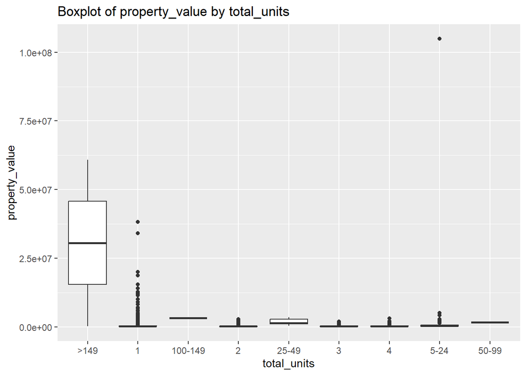

```r
#From the description, I find that total_units denote the number of individual dwelling units related to the property securing the covered loan or, in the case of an application, proposed to secure the covered loan. So I explore the relationship between total_units and property_value.
##From the boxplot, we can conclude that except total_units>149, there is not a strong relationship between total_units and property_value. Some strong relationship may exist between property_value and other loan information related features, but they are not applicable before I address their NA values. So we can not apply Regression imputation to fill all NA values of property_value. Instead, I will apply Mean imputation for NA values in property_value (those values can not be calculated from 100 * loan_amount/loan_to_value_ratio) and then generate loan_to_value_ratio by 100 * loan_amount/property_value.
ggplot(loan_numerical_data, aes(x=total_units, y=property_value_double)) +
  geom_boxplot() +
  labs(title="Boxplot of property_value by total_units", x="total_units", y="property_value")
```

```r
#Fill NA values of property_value_double with loan_amount/loan_to_value_ratio_double if loan_to_value_ratio_double is not NA
loan_numerical_data$property_value_double <- ifelse(is.na(loan_numerical_data$property_value_double) & !is.na(loan_numerical_data$loan_to_value_ratio_double),                         (loan_numerical_data$loan_amount * 100.0 )/loan_numerical_data$loan_to_value_ratio_double, loan_numerical_data$property_value_double)

#calculate the mean without NA
mean_property_value_double <- mean(loan_numerical_data$property_value_double, na.rm = TRUE)

#fill NA of property_value_double with mean.
loan_numerical_data$property_value_double <- ifelse(is.na(loan_numerical_data$property_value_double),
             mean_property_value_double,
             loan_numerical_data$property_value_double)

#fill NA of loan_to_value_ratio_double with loan_amount/property_value_double *100
loan_numerical_data$loan_to_value_ratio_double <- ifelse(is.na(loan_numerical_data$loan_to_value_ratio_double),
     (100 * loan_numerical_data$loan_amount)/loan_numerical_data$property_value_double,
     loan_numerical_data$loan_to_value_ratio_double)

# Some features have too direct relationship with the target
unique(loan_numerical_data[!is.na(loan_numerical_data$interest_rate) &

##if interest_rate is not NA and not "Exempt", the action_take must be 1
loan_numerical_data$interest_rate!="Exempt",c("action_taken")])
```

```
## [1] 1
```